# Plots/ggplot2

⌂ Contents 📁 Materials ↓ Practice ← Matrices Plot axes/scales →

The [ggplot2](https://ggplot2.tidyverse.org/) library is a part of the `tidyverse` package.  
Citing the original description:

> “`ggplot2` is a system for declaratively creating graphics, based on **The Grammar of Graphics**. You provide the data, tell `ggplot2` how to map variables to aesthetics, what graphical primitives to use, and it takes care of the details”.

*Remember to use `library( tidyverse )` at the beginning of your R Markdown document.*  
*Load the `pulse.csv` table into the `pulse` variable.*  
*Practice in an R Markdown document and `Knit` it regularly to see the generated report.*

## A simple scatter plot

When you use `ggplot2`, you compose a plot by “adding” components. Here are some examples:

- `ggplot( pulse )`: Always the first component. It starts a new plot for data from the variable `pulse` (a `tibble` or a `data.frame`).
- `aes( x = weight )`: aesthetics – Sets usage of the data column `weight` for the `x` axis.
- `geom_point()`: Sets the scatter plot geometry (requires at least `x` and `y`).

Now enter the following code and create a simple scatter plot (also `Knit` the document):

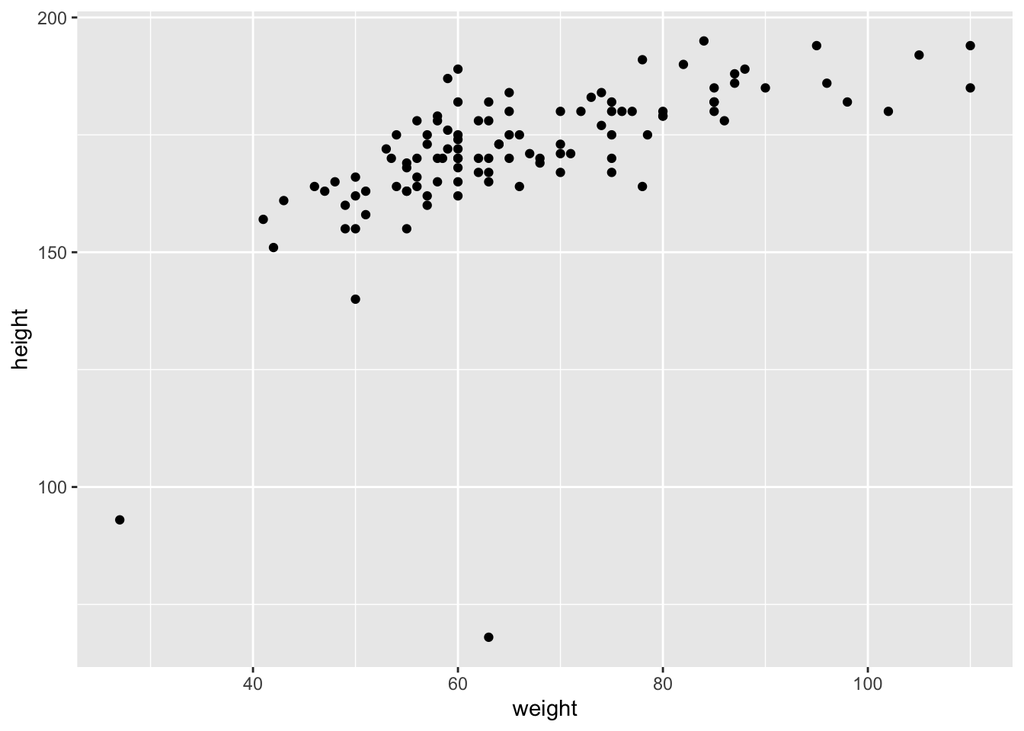

```r
ggplot( pulse ) +
  aes( x = weight, y = height ) +
  geom_point()
```

## Aesthetics

Open `Help` for the command `geom_point` and find there the section `Aesthetics`.  
There you can find keywords to specify **aesthetics** known by `geom_point`: position, color, shape of the points, …

### Fixed: all points identical

Type the following example code and generate the plot.  
Regenerate the plot for another color (google-search to find allowed “[R color names](https://www.google.com/search?q=R+color+names)”):

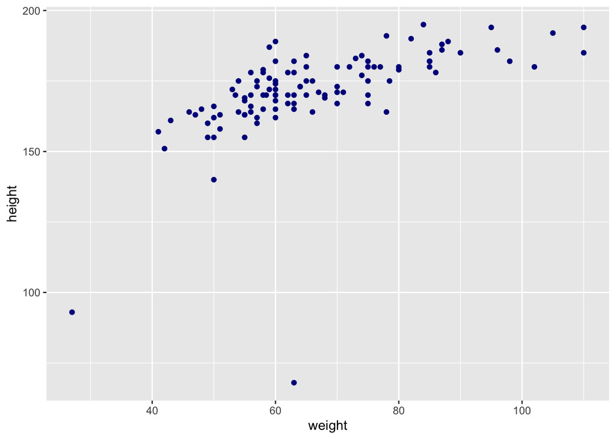

```r
ggplot( pulse ) +
  aes( x = weight, y = height ) +
  geom_point( color = "darkblue" )
```

Type the following code with different values of `size` (e.g.: 0.5, 1, 2, 5) to see the effect:

```r
ggplot( pulse ) +
  aes( x = weight, y = height ) +
  geom_point( color = "darkblue", size = 5 )
```

Now, add and modify `alpha` (range from 0.0 to 1.0) to change transparency:

```r
ggplot( pulse ) +
  aes( x = weight, y = height ) +
  geom_point( color = "darkblue", size = 5, alpha = 0.5 )
```

Next, google-search to find allowed “[R point shapes](https://www.google.com/search?q=R+point+shapes)”.  
Shapes are numbered (range: 0..25). Try:

```r
ggplot( pulse ) +
  aes( x = weight, y = height ) +
  geom_point( shape = 24, size = 3 )
```

Note, that some shapes (21..25) might be drawn with two different colors.  
They are specified with `color` and `fill` aesthetics. Try:

```r
ggplot( pulse ) +
  aes( x = weight, y = height ) +
  geom_point( shape = 24, size = 3, color = "blue", fill = "lightblue" )
```

### Variable: points diffier

Variable **aesthetics** need to be specified as arguments to `aes( ... )` function.  
For example, type the following code to make color of the points dependent on the `exercise` column of `pulse`.  
Note, that the library recognizes that the variable is **categorical** and creates an appropriate legend.  
Scale colors are assigned automatically (other possibilities will be discussed in the next section).

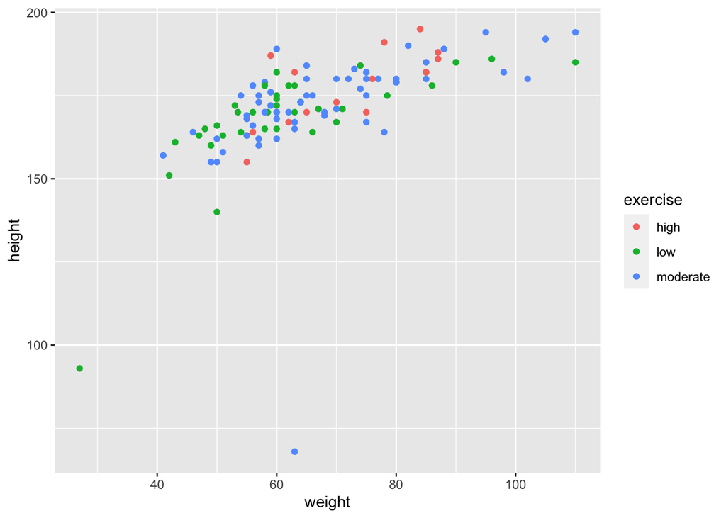

```r
ggplot( pulse ) +
  aes( x = weight, y = height, color = exercise ) +
  geom_point()
```

The `pulse1` variable is **continuous** (not categorical).  
Try the following and observe the change in the legend (as above, the scale is created automatically).

```r
ggplot( pulse ) +
  aes( x = weight, y = height, color = pulse1 ) +
  geom_point()
```

### Combined

Naturally, it is possible to combine variable and fixed aesthetics. Try:

```r
ggplot( pulse ) +
  aes( x = weight, y = height, size = pulse1, fill = exercise ) +
  geom_point( shape = 21, alpha = 0.65, color = "black" )
```

Note, that the notation is quite flexible.  
Check, that indeed the same chart is generated by:

```r
ggplot( pulse, aes( x = weight ) ) +
  aes( y = height ) +
  aes( fill = exercise ) +
  geom_point( shape = 21, alpha = 0.65, color = "black", aes( size = pulse1 ) )
```

⌂ Contents 📁 Materials ↓ Practice ← Matrices Plot axes/scales →